# Finding systematic evidence: search and scan principles

Zhengting (Johnathan) He, MBBS.

2021/4/6

Due to limited time and overwhelming details, I did not have time to draft this document in a traditional way, but to use RMarkDown instead, thus the format may not be quite good in some cases. Sorry about that. If you are interested in how I made this document, or would like to change the format to a style that you prefer, you can find my original code at https://github.com/hezht3/DKU_workshop_search-scan. Please feel free to clone this repo. If you have any questions or suggestions, please feel free to contact me at zhengting.he@dukekunshan.edu.cn.

# Brief intro about myself

- MBBS. of Oral Medicine, Guanghua School of Stomatology, Sun Yat-sen University
- MHS candidate in Epidemiology, Bloomberg School of Public Health, Johns Hopkins University
- Intern Research Fellow for NCDs research, Global Health Research Center, Duke Kunshan University

# 1. Why do we need to search literature systematically?

# 1.1 Why do we need to search literature systematically?

- Why do we need to conduct a systematic review?
  - Evidence is overwhelming but inconsistent
- Why do we need to systematically review literatures in our studies?
  - Ensure not to duplicate the work of others
  - Gain insights from other’s work

# 1.2 What is a Systematic Review?

- Focuses on a specific question
- Uses explicit, pre-planned scientific methods to **identify, select, appraise, and summarize** similar but separate studies
- Cochrane handbook:
  - Systematic reviews seek to **collate evidence that fits pre-specified eligibility criteria** in order to answer **a specific research question**. They aim to **minimize bias** by using explicit, systematic methods documented in advance with a protocol.

# 1.3 Types of reviews

- All reviews
  - Reviews that are not systematic (traditional, narrative reviews)
  - Systematic reviews
    - **Qualitative** systematic reviews
    - **Quantitative** systematic reviews: systematic reviews with **meta-analyses**

# 1.4 If you would like to know more

- Cochrane Handbook for Systematic Reviews of Interventions: https://training.cochrane.org/handbook/current
- Introduction to Systematic Review and Meta-Analysis. Coursera. Johns Hopkins Bloomberg School of Public Health: https://www.coursera.org/learn/systematic-review/home/welcome
- Chinese textbook by Huaxi School of Public Health: 系统评价、meta-分析设计与实施方法

# 2. How to conduct a systematic electrical searching

**Before the start of the searching, it is very important to formulate a draft study protocol in a formal systematic review. Key references and draft protocol will help you to further formulate search strategy and study selection criteria, and the pilot study in these 2 stages will further help you to finish a final study protocol.**

# 2.1 Starting point for developing a search strategy: break your research question into concepts (PICOS)

- consider the main concepts being examined in a review: **PICOS**
  - The **review PICO** (planned at the protocol stage) is the **PICO** on which eligibility of studies is based (what will be included and what excluded from the review).
  - The **PICO of the included studies** (determined at the review stage) is what was actually investigated in the included studies.
- PICOS
  - **P**opulation
  - **I**ntervention(s)
  - **C**omparison(s)
  - **O**utcome
  - **S**tudy design

# 2.1.1 Components of research questions: “PICOS/PECOS” principle

- **P**: Patients or populations
  - Define condition or disease, including explicit diagnostic criteria
  - Population and setting of interest (age, race, sex, community, hospital, outpatient)
- **I/E**: Intervention/exposure
  - Timing of exposures
  - Route of administration
  - Dose intensity
  - Duration of exposure or therapy
- **C**: Comparison group(s)
  - For trials: placebo, standard therapy, no treatment
  - For epi: no exposure, non-cases (hospital, neighborhood, etc.)
- **O**: Outcome
  - Criteria for defining
  - Important to cunsumers, providers
  - Unpublished data?
- **S**: Study design
  - Experimental studies or observational studies (Levels of evidence: https://www.cebm.ox.ac.uk/resources/levels-of-evidence/oxford-centre-for-evidence-based-medicine-levels-of-evidence-march-2009)
  - Details of study design, eg. placebo in control group, endpoint blinding, follow-up time

# 2.2.2 Examples of breaking down the research questions

- Combined lifestyle factors, all-cause mortality and cardiovascular disease: a systematic review and meta-analysis of prospective cohort studies
  - P: N/A (without the outcome of interests at the start of the study)
  - E: combined lifestyle factors (healthy?)
  - C: combined lifestyle factors (non-healthy?)
  - O: all-cause mortality and cardiovascular disease
  - S: a systematic review and meta-analysis of prospective cohort studies
- Lifestyle factors, cardiovascular disease and all-cause mortality in middle-aged and elderly women: a systematic review and meta-analysis
  - P: middle-aged and elderly women (without the outcome of interests at the start of the study)
  - E: lifestyle factors (healthy?)
  - C: lifestyle factors (non-healthy?)
  - O: cardiovascular disease and all-cause mortality
  - S: a systematic review and meta-analysis (of cohort studies)

# 2.2 Structure of a search strategy

- Structure:
  - **a broad set of search terms** gathered for each concept
  - combined with the **OR** Boolean operator to achieve sensitivity within concepts
  - combined with the **AND** Boolean operator for results of each concept
- **Structure from my point of view:**
  - **word[field] + logic**

# 2.2.1 Word

# 2.2.1.1 Find synonyms for text words

- You need to start with **simple search strategy**
- Start with the general format:
  - (Population OR synonym #1 OR synonym #2) AND
  - (Intervention OR synonym #1 OR synonym #2) AND
  - [if applicable] (Comparator OR synonym #1 OR synonym #2) AND
  - [if applicable] (Outcome OR synonym #1 OR synonym #2)
  - Add study type filter terms

# Take “healthy lifestyle and mortality” as an example

[figure not shown]

# Take “healthy lifestyle and mortality” as an example

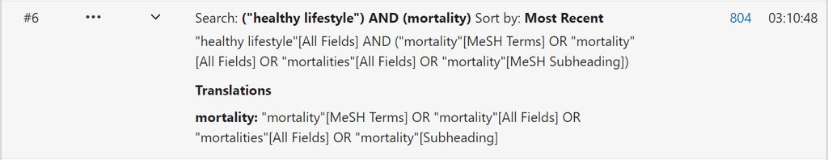

# Take “healthy lifestyle and mortality” as an example

[figure not shown]

# Take “healthy lifestyle and mortality” as an example

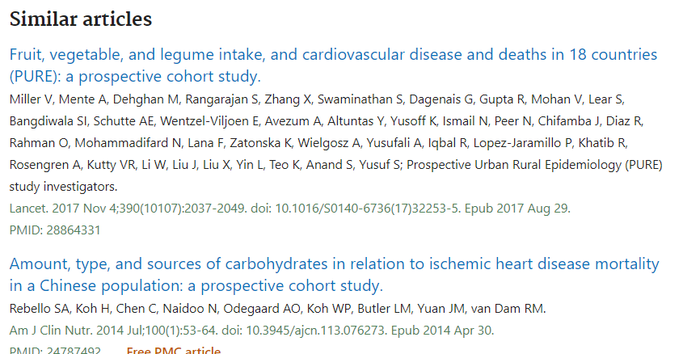

# Take “healthy lifestyle and mortality” as an example

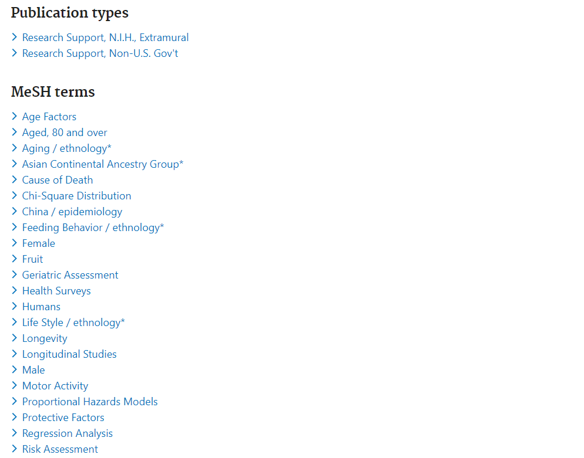

- **Those Mesh terms end with "*" are important mesh terms that you need to pay special attention.**

# Take “healthy lifestyle and mortality” as an example

[figure not shown]

# Take “healthy lifestyle and mortality” as an example

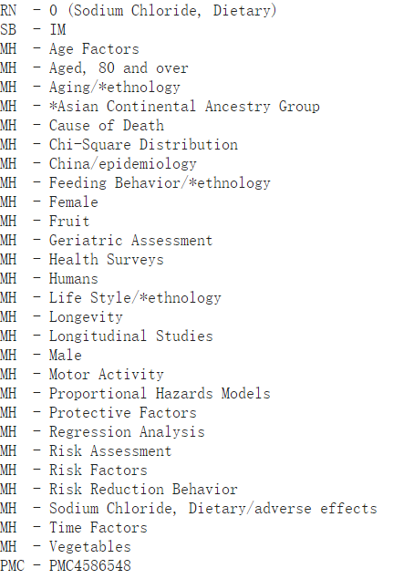

- Use **key words** and **mesh terms** in known articles to expand synonyms and build search strategy

# 2.2.1.2 Use **controlled vocabulary** when available

- **text words** and **controlled vocabulary**
  - **text word**: the terms occurring in the title, abstract, or other fields
  - **controlled vocabulary**: standardized subject terms assigned to the references by indexers
- Use both **text words** and **controlled vocabulary**
  - If you use only keywords, you could miss articles that don’t use your precise terms
  - If you use only controlled vocabulary, you could miss articles that have not been indexed yet or that have older indexing

# 2.2.1.2.1 PubMed: **MeSH Database**

[figure not shown]

# 2.2.1.2.1 PubMed: **MeSH Database**

[figure not shown]

# 2.2.1.2.1 PubMed: **MeSH Database**

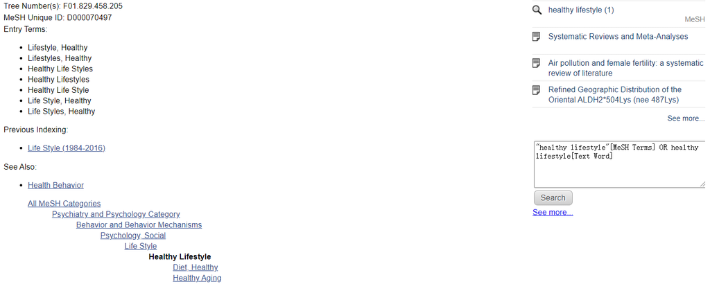

# 2.2.1.2.1 PubMed: **MeSH Database**

[figure not shown]

# 2.2.1.2.2 MEDLINE (Ovid interface): **MeSH Database**

[figure not shown]

# 2.2.1.2.3 Embase: **Emtree**

[figure not shown]

# 2.2.1.2.3 Embase: **Emtree**

[figure not shown]

# 2.2.1.2.4 Web of Science: no controlled vocabulary available

# 2.2.1.3 Other issues on **Consistency**

- Plurals: Acuity, acuities
- Abbreviations: CVD for cardiovascular diseases
- Synonyms: variation, mutation, polymorphism
- Spelling variations: Randomized/randomised
- Scope: cardiovascular disease, heart disease

# 2.2.2 Field

- We do not have time to discuss about details here. Generally speaking, we mostly use “[Title/abstract]” as the search field.
- Here are the common field tags for PubMed. Other databases have similar fields.
  - MeSH: mh
  - Text word: tw
  - Title and abstract: tiab
  - Title: ti
  - Date:dp
  - Author: au
  - Publication type: pt
  - All fields: all

# 2.2.3 Logic

# 2.2.3.1 Boolean logic

- similiar to coding: **AND**, **OR**, **NOT**
  - “healthy lifestyle” **AND** mortality
  - “healthy lifestyle” **OR** “healthy diet habit”
  - “healthy lifestyle” **NOT** “animal”

# 2.2.3.2 Proximity searching

- **NEAR/ADJ**
  - healthy **adj1** lifestyle
  - **PubMed and Web of Science do not have proximit searching function**
  - So we suggest you to use **MEDLINE** instead of **PubMed** as it has proximity searching (adj) function

# 2.2.3.3 Truncate searching

- similiar to coding: * or $
  - varian*: variant, variance

# 2.2.4 Specific for **study type**

- There are existing sensitivie search strategy for different study type
- eg. Highly Sensitive Search Strategy for identifying randomized trials in PubMed:
  - #1 randomized controlled trial [pt]
  - #2 controlled clinical trial [pt]
  - #3 randomized [tiab]
  - #4 placebo [tiab]
  - #5 drug therapy [sh]
  - #6 randomly [tiab]
  - #7 trial [tiab]
  - #8 groups [tiab]
  - #9 #1 or #2 or #3 or #4 or #5 or #6 or #7 or #8
  - #10 animals [mh] not (humans [mh] and animals [mh])
  - #11 #9 not #10
- eg. Highly Sensitive Search Strategy for identifying randomized trials in Ovid:
  - #1 randomized controlled trial.pt.
  - #2 controlled clinical trial.pt.
  - #3 randomized.ab.
  - #4 placebo.ab.
  - #5 drug therapy.fs.
  - #6 randomly.ab.
  - #7 trial.ab
  - #8 groups.ab.
  - #9 1 or 2 or 3 or 4 or 5 or 6 or 7 or 8
  - #10 animals.sh. not(humans.sh. and animals.sh)
  - #11 9 not 10

# 2.3 Fit search strategy to each database

# Common databases

- PubMed
- MEDLINE (Ovid interface)
- EMBASE
- Cochrane Central Register of Controlled Trials (CENTRAL) & Cochrane Database of Systematic Review
- Citation databases: Web of Science
- Other databases:
  - Citation databases: Scopus
    - Dissertations, thesis databases: ProQuest
  - National and regional databases (often local language): LILACS
  - Subject-specific databases:
    - CINAHL
    - PsychINFO
    - OTSeeker
  - Gray literature databases: Opengrey
- **Do not forget the importance of Google Scholar, though it has not been included as a common databased in most systematic reviews, it will be really helpful for you to find initial key literatures, and to make sure whether your searching is comprehensive.**

# Example

- Take this article as an example “Zhang Y, Pan X F, Chen J, et al. Combined lifestyle factors and risk of incident type 2 diabetes and prognosis among individuals with type 2 diabetes: a systematic review and meta-analysis of prospective cohort studies[J]. Diabetologia, 2020, 63(1): 21-33.”
- “In brief, the search terms included the Medical Subject Heading terms and related exploded versions as well as keywords in titles or abstracts related to the following themes: ‘diabetes’, ‘cardiovascular disease’, ‘cancer’, ‘mortality’, ‘combined’, ‘lifestyle’ and ‘cohort studies’. The search themes were then combined using the Boolean operator ‘or’ for the four health outcomes (diabetes, CVD, cancer and mortality) and then combined with other themes using ‘and’.”
- You can try to find synonyms based on the brief search strategy the author provided here, and to try to search on PubMed and MEDLINE, and to see how many articles your search strategy will retrieve, and how many articles the author’s search strategy will retrieve.
- You can also try to modify the search strategy the author provided, eg. to use combin*[Title/Abstract] instaed of “combination[Title/Abstract] OR combinations[Title/Abstract] OR combined[Title/Abstract]”, and to see how the searching result changes.
  - PubMed
    - #1 (combination[Title/Abstract] OR combinations[Title/Abstract] OR combined[Title/Abstract] OR composite[Title/Abstract] OR integrated[Title/Abstract] OR interaction[Title/Abstract] OR interactions[Title/Abstract] OR “joint effect”[Title/Abstract] OR “joint effects”[Title/Abstract] OR “merged effect”[Title/Abstract] OR “merged effects”[Title/Abstract] OR score[Title/Abstract] OR scores[Title/Abstract] OR “adherence to”[Title/Abstract] OR “adhere to”[Title/Abstract] OR “adhered to”[Title/Abstract] OR collective[Title/Abstract] OR cumulative[Title/Abstract] OR multiple[Title/Abstract])
    - #2 (life style[Mesh] OR risk reduction behavior[Mesh] OR health behavior[Mesh] OR life style[Title/Abstract] OR life styles[Title/Abstract] OR “health factor”[Title/Abstract] OR “health factors”[Title/Abstract] OR lifestyle[Title/Abstract] OR lifestyles[Title/Abstract] OR “low risk”[Title/Abstract] OR “low risks”[Title/Abstract] OR prevention guideline[Title/Abstract] OR prevention guidelines[Title/Abstract] OR “protective factor”[Title/Abstract] OR “protective factors”[Title/Abstract] OR “risk reduction behavior”[Title/Abstract] OR “risk reduction behaviour”[Title/Abstract] OR “risk reduction behaviors”[Title/Abstract] OR “risk reduction behaviours”[Title/Abstract] OR “health behavior”[Title/Abstract] OR “health behaviour”[Title/Abstract] OR “health behaviors”[Title/Abstract] OR “health behaviours”[Title/Abstract] OR “healthy behavior”[Title/Abstract] OR “healthy behaviour”[Title/Abstract] OR “healthy behaviors”[Title/Abstract] OR “healthy behaviours”[Title/Abstract] OR “risk behavior”[Title/Abstract] OR “risk behaviour”[Title/Abstract] OR “risk behaviors”[Title/Abstract] OR “risk behaviours”[Title/Abstract] OR “modifiable factors”[Title/Abstract])
    - #3 (cohort studies[Mesh] OR incidence[Mesh] OR survival analysis[Mesh] OR early diagnosis[Mesh] OR prognosis[Mesh] OR prospective[Title/Abstract] OR prospectively[Title/Abstract] OR cohort[Title/Abstract] OR follow up[Title/Abstract] OR “followed up”[Title/Abstract] OR longitudinal[Title/Abstract] OR “nested case-control”[Title/Abstract] OR “nested case control”[Title/Abstract] OR incidence[Title/Abstract] OR “early diagnosis”[Title/Abstract] OR predict[Title/Abstract] OR predicts[Title/Abstract] OR predicted[Title/Abstract] OR predicting[Title/Abstract] OR prediction[Title/Abstract] OR predictions[Title/Abstract] OR predictive[Title/Abstract] OR prognosis[Title/Abstract] OR prognoses[Title/Abstract] OR prognostic[Title/Abstract] OR survival[Title/Abstract])
    - #4 ((#1) AND #2) AND #3
    - #5 (death[Mesh] OR mortality[Mesh] OR death[Title/Abstract] OR deaths[Title/Abstract] OR fatal[Title/Abstract] OR fatality[Title/Abstract] OR fatalities[Title/Abstract] OR “life expectancy”[Title/Abstract] OR “life expectancies”[Title/Abstract] OR mortality[Title/Abstract] OR mortalities[Title/Abstract] OR survival[Title/Abstract] OR survive[Title/Abstract] OR survived[Title/Abstract] OR survives[Title/Abstract] OR surviving[Title/Abstract])
    - #6 (diabetes mellitus, type 2[Mesh] OR diabetes[Title/Abstract] OR diabetic[Title/Abstract] OR diabetics[Title/Abstract] OR T2D[Title/Abstract] OR T2DM[Title/Abstract] OR NIDDM[Title/Abstract])
    - #7 (cardiovascular diseases[Mesh] OR cardiovascular[Title/Abstract] OR CVD[Title/Abstract] OR “heart disease”[Title/Abstract] OR “heart diseases”[Title/Abstract] OR “myocardial ischemia”[Title/Abstract] OR “myocardial ischaemia”[Title/Abstract] OR AMI[Title/Abstract] OR IHD[Title/Abstract] OR CHD[Title/Abstract] OR “coronary artery disease”[Title/Abstract] OR “coronary artery diseases”[Title/Abstract] OR CAD[Title/Abstract] OR “myocardial infarction”[Title/Abstract] OR “heart infarction”[Title/Abstract] OR “acute coronary syndrome”[Title/Abstract] OR ACS[Title/Abstract] OR “heart failure”[Title/Abstract] OR “sudden cardiac death”[Title/Abstract] OR “cerebrovascular disorder”[Title/Abstract] OR “cerebrovascular disorders”[Title/Abstract] OR “cerebrovascular accident”[Title/Abstract] OR “cerebrovascular accidents”[Title/Abstract] OR “cerebrovascular attack”[Title/Abstract] OR “cerebrovascular attacks”[Title/Abstract] OR CVA[Title/Abstract] OR “cerebrovascular disease”[Title/Abstract] OR “cerebrovascular diseases”[Title/Abstract] OR CBVD[Title/Abstract] OR “cerebral arterial disease”[Title/Abstract] OR “cerebral arterial diseases”[Title/Abstract] OR stroke[Title/Abstract] OR strokes[Title/Abstract] OR apoplex[Title/Abstract])
    - #8 (neoplasms[Mesh] OR neoplasm[Title/Abstract] OR neoplasms[Title/Abstract] OR neoplasia[Title/Abstract] OR cancer[Title/Abstract] OR cancers[Title/Abstract] OR carcinoma[Title/Abstract] OR carcinomas[Title/Abstract] OR tumour[Title/Abstract] OR tumours[Title/Abstract] OR tumor[Title/Abstract] OR tumors[Title/Abstract] OR malignancy[Title/Abstract] OR malignancies[Title/Abstract])
    - #9 (((#5) OR #6) OR #7) OR #8
    - #10 (#9) AND #4
  - EMBASE
    - 1 exp lifestyle/
    - 2 exp health behavior/
    - 3 (life style or life styles or health factor or health factors or lifestyle or lifestyles or low risk or low risks or prevention guideline or prevention guidelines or protective factor or protective factors or risk reduction behavior or risk reduction behaviour or risk reduction behaviors or risk reduction behaviours or health behavior or health behaviour or health behaviors or health behaviours or healthy behavior or healthy behaviour or healthy behaviors or healthy behaviours or risk behavior or risk behaviour or risk behaviors or risk behaviours or modifiable factors).ti. or (life style or life styles or health factor or health factors or lifestyle or lifestyles or low risk or low risks or prevention guideline or prevention guidelines or protective factor or protective factors or risk reduction behavior or risk reduction behaviour or risk reduction behaviors or risk reduction behaviours or health behavior or health behaviour or health behaviors or health behaviours or healthy behavior or healthy behaviour or healthy behaviors or healthy behaviours or risk behavior or risk behaviour or risk behaviors or risk behaviours or modifiable factors).ab.
    - 4 1 or 2 or 3
    - 5 (combination or combinations or combined or composite or integrated or interaction or interactions or joint effect or joint effects or merged effect or merged effects or score or scores or adherence to or adhere to or adhered to or collective or cumulative or multiple).ti. or (combination or combinations or combined or composite or integrated or interaction or interactions or joint effect or joint effects or merged effect or merged effects or score or scores or adherence to or adhere to or adhered to or collective or cumulative or multiple).ab.
    - 6 exp cohort analysis/
    - 7 exp incidence/
    - 8 exp survival analysis/
    - 9 exp early diagnosis/
    - 10 (prospective or prospectively or cohort or follow up or followed up or longitudinal or nested case-control or nested case control or incidence or early diagnosis or predict or predicts or predicted or predicting or prediction or predictions or predictive or prognosis or prognoses or prognostic or survival).ti. or (prospective or prospectively or cohort or follow up or followed up or longitudinal or nested case-control or nested case control or incidence or early diagnosis or predict or predicts or predicted or predicting or prediction or predictions or predictive or prognosis or prognoses or prognostic or survival).ab.
    - 11 exp prognosis/
    - 12 6 or 7 or 8 or 9 or 10 or 11
    - 13 exp death/
    - 14 exp mortality/
    - 15 exp survival/
    - 16 (death or deaths or fatal or fatality or fatalities or life expectancy or life expectancies or mortality or mortalities or survival or survive or survived or survives or surviving).ti. or (death or deaths or fatal or fatality or fatalities or life expectancy or life expectancies or mortality or mortalities or survival or survive or survived or survives or surviving).ab.
    - 17 13 or 14 or 15 or 16
    - 18 exp non insulin dependent diabetes mellitus/
    - 19 (diabetes or diabetic or diabetics or T2D or T2DM or NIDDM).ti. or (diabetes or diabetic or diabetics or T2D or T2DM or NIDDM).ab.
    - 20 18 or 19
    - 21 exp cardiovascular disease/
    - 22 (cardiovascular or CVD or heart disease or heart diseases or myocardial ischemia or myocardial ischaemia or AMI or IHD or CHD or coronary artery disease or coronary artery diseases or CAD or myocardial infarction or heart infarction or acute coronary syndrome or ACS or heart failure or sudden cardiac death or cerebrovascular disorder or cerebrovascular disorders or cerebrovascular accident or cerebrovascular accidents or cerebrovascular attack or cerebrovascular attacks or CVA or cerebrovascular disease or cerebrovascular diseases or CBVD or cerebral arterial disease or cerebral arterial diseases or stroke or strokes or apoplex).ti. or (cardiovascular or CVD or heart disease or heart diseases or myocardial ischemia or myocardial ischaemia or AMI or IHD or CHD or coronary artery disease or coronary artery diseases or CAD or myocardial infarction or heart infarction or acute coronary syndrome or ACS or heart failure or sudden cardiac death or cerebrovascular disorder or cerebrovascular disorders or cerebrovascular accident or cerebrovascular accidents or cerebrovascular attack or cerebrovascular attacks or CVA or cerebrovascular disease or cerebrovascular diseases or CBVD or cerebral arterial disease or cerebral arterial diseases or stroke or strokes or apoplex).ab.
    - 23 21 or 22
    - 24 exp neoplasm/
    - 25 (neoplasm or neoplasms or neoplasia or cancer or cancers or carcinoma or carcinomas or tumour or tumours or tumor or tumors or malignancy or malignancies).ti. or (neoplasm or neoplasms or neoplasia or cancer or cancers or carcinoma or carcinomas or tumour or tumours or tumor or tumors or malignancy or malignancies).ab.
    - 26 24 or 25
    - 27 17 or 20 or 23 or 26
    - 28 4 and 5 and 12 and 27

# Example

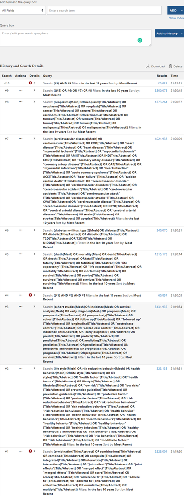

# 2.4 Document your searching

# 2.4.1 Bibliographic Management Software

- Download and store results of electronic searches in EndNote
  - EndNote is most popularly used, and is also purchased by Duke and DKU for faculty, staff, and students
  - EndNote 20 version is not quite perfect, so I still recommend you to use EndNote X9
  - Win and Mac version can be downloaded here: https://duke.box.com/s/yp0k9jro6t4247we6f0xv2xn2ndkqiz1
- Other similar softwares
  - ProCite
  - Reference Manager
  - RefWorks
  - QUOSA
  - Mendeley: good to be used in reading fulltext https://www.mendeley.com/?interaction_required=true
  - Sciwheel: also Duke support, online interface https://duke.box.com/s/7k9ec7vf4rnr3rh1c0f8qoiiprdf3yr6

# 2.4.2 Import your searching result from PubMed

- Download citations

[figure not shown]

[figure not shown]

[figure not shown]

# 2.4.3 Import your searching result from MEDLINE

[figure not shown]

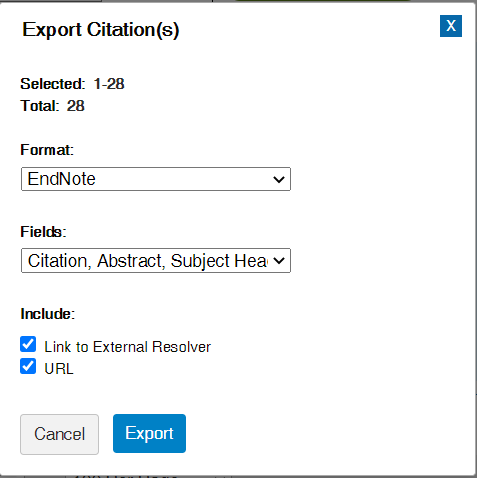

# 2.4.4 Import your searching result from EMBASE

[figure not shown]

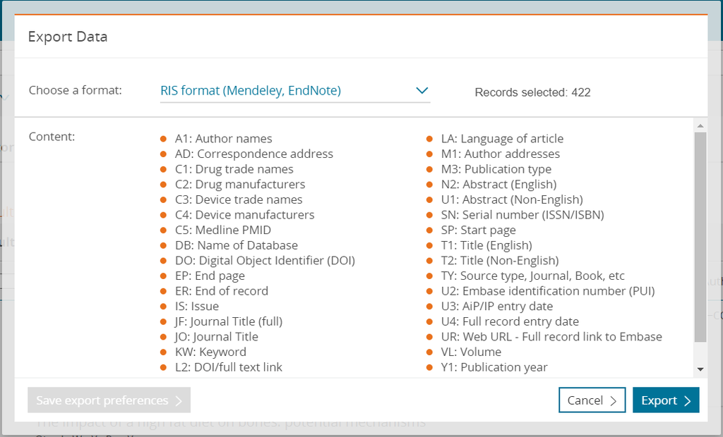

# 2.4.5 Use EndNote to manage literatures

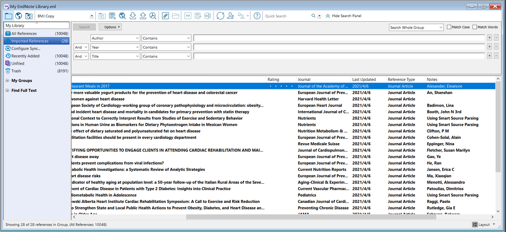

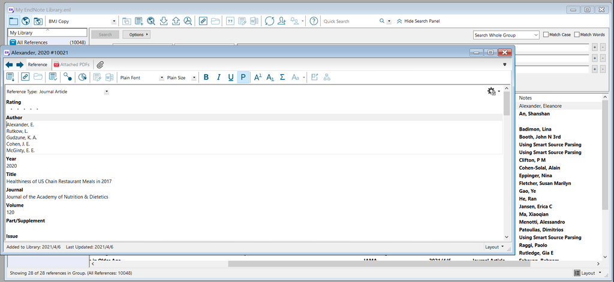

# 2.5 Systematic Snowballing

- Use included articles as a source to identify missing studies:
  - Reference lists: Check **cited** articles = backward searching
  - Web of Science, SCOPUS: Check **citing** articles = forward searching
  - “Related articles”/ “Find Similar” in MEDLINE and Embase: Also could use to find new terms to expand your search strategy

# 2.6 PRISMA Flow of Information

- To keep record of complicated searching and scanning, I strongly encourage you to document infromation in PRISMA flow diagram. Details can be found here: http://www.prisma-statement.org/PRISMAStatement/FlowDiagram

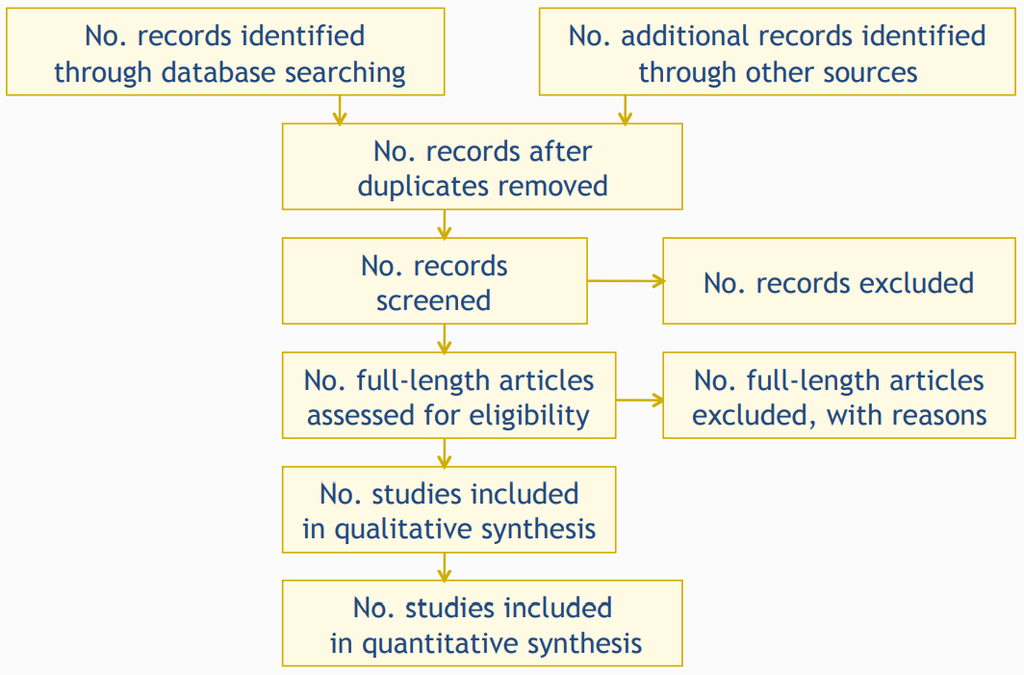

# 2.7 Summary on searching

- Create a comprehensive, sensitive searching (comprehensive vs. sensitive)
- Starting with your question/PICOS, build the search strategy on the structure of word, field, and logic
- Use all electronic resources
- Document when, where, and how you searched and what you found
- We are not experts on searching, if your team cannot solve a problem in searching, it is time to **Ask a Librarian**. It will be also helpful to consult a content expert.

# 3. How to conduct study selection?

# 3.1 The process of study selection

- Import all citation records retrieved from all databases, remove duplicates (both electronic and manually), set up a reference library
  - Electronic: In EndNote, select **Reference**, **Find duplicates**
  - Manual: recommend to perform at least 2 rounds, first sort literature by **Author** and remove duplicates, and sort literature by **Title** and remove duplicates
- Scan literature by **Title/Abstract**, remove articles that are clearly not fit with your research topic
- Find full text of all articles left
- Group the left articles by outcome of interests or different outcomes
- Scan literature by **Full text**, contact the author if needed for missing information
- Final decision on included articles

# 3.2 Study selection critera: build based on **PICOS**

- **P**opulation
  - diagnostic criteria of diseases
  - main characteristics of participants
  - demographic characteristics
  - research institutions
  - who make the diagnosis
  - participants needed to be excluded from systematic review
  - how to deal with studies only contained a subgroup of the study population
- **I**ntervention/**E**xposure/**C**omparison
  - what is the intervention/exposure/comparison of interests
  - how to deal with heterogeneity in intervention, eg. doses, treatment period
  - how to deal with studies only contained part of the intervention of interests
  - how to deal with studies not only included the intervention of interests
- **O**utcome
  - whether the outcome is of significance to patients and decision-makers in clinical work
  - primary outcomes are 2 or 3 of the target outcomes
  - secondary outcomes are the rest target outcomes, or outcomes to evaluate the effects of the interventions
  - outcomes should contain potential or certified adverse-effect
  - consider all outcomes that are related to decision-making, including economic factors
  - consider the scope and time for evluating the outcomes
- **S**tudy design
  - Experimental studies or observational studies (Levels of evidence: https://www.cebm.ox.ac.uk/resources/levels-of-evidence/oxford-centre-for-evidence-based-medicine-levels-of-evidence-march-2009)

# 3.3 Critical points in study selection

- The **sequence** of study selection criteria
- Study selection is a **subjective** process
- **Blinding**
- **Pilot studies**
- Follow your **protocol**
- Document the reasons for **exclusion**

# Thank you

- Similar to programming, it is hardly possible to cover all details in a workshop
- The fastest way to progress is to **try it**, and to find solutions when meeting problems
- Hopefully you will find this process interesting and good luck

# References

- 刘鸣. 系统评价、Meta-分析设计与实施方法.人民卫生出版社
- Kay Dickersin, Tianjing Li. Introduction to Systematic Review and Meta-Analysis. Coursera
- Julian Higgins, James Thomas, et al. Cochrane Handbook for Systematic Reviews of Interventions. Cochrane Training
- Page MJ, McKenzie JE, Bossuyt PM, Boutron I, Hoffmann TC, Mulrow CD, et al. The PRISMA 2020 statement: an updated guideline for reporting systematic reviews. BMJ 2021;372:n71. doi: 10.1136/bmj.n71